# Data Analysis Skill Test - 4intelligence

Luis Gustavo Bettoni

27/11/2020

#### This document contains the resolution and the code of the two cases provided for the data analysis skill test. The exercises were solved with R and this report was produced using Rmarkdown. We first load all packages that will be used.

```r
# load libraries
library(dplyr)    # general tool
library(tidyr)    # general tool
```

```r
library(ggplot2)  # graphs
library(corrplot) # plot correlation
library(Hmisc)
library(plm)      # panel
library(fpp2)     # forecast
library(stats)    # forecast
library(reshape)  # reshape
```

## 1. Case 1

We are provided the series for TFP at constant national prices (2005 = 1) for United States (USA), Canada (CAN) and Mexico (MEX) between 1950 and 2011. We are asked to describe this data through an explanatory data analysis and to provide forecast over a 10 years period. First we import the data and rename the variables.

```r
# import data base
tfp <- read.csv("TFP.csv")

# rename
tfp<-tfp%>%
  dplyr::rename(country="isocode",
                tfp="rtfpna")
```

### 1.1 Exploratory data analysis

We begin by checking whether there is any problem with the data, such as misreports or missing values.

```r
# quick summary of database
summary(tfp)
```

```
##    country               year           tfp
##  Length:186         Min.   :1950   Min.   :0.6171
##  Class :character   1st Qu.:1965   1st Qu.:0.8551
##  Mode  :character   Median :1980   Median :0.9950
##                     Mean   :1980   Mean   :0.9756
##                     3rd Qu.:1996   3rd Qu.:1.0463
##                     Max.   :2011   Max.   :1.3837
```

We can see that data goes from 1950 to 2011 and we do not have any missing observations. Further, TFP varies from 0.6171 to 1.3837, with an average of 0.9756. Now we analyze data by country. First we plot the evolution of TFP series for each country.

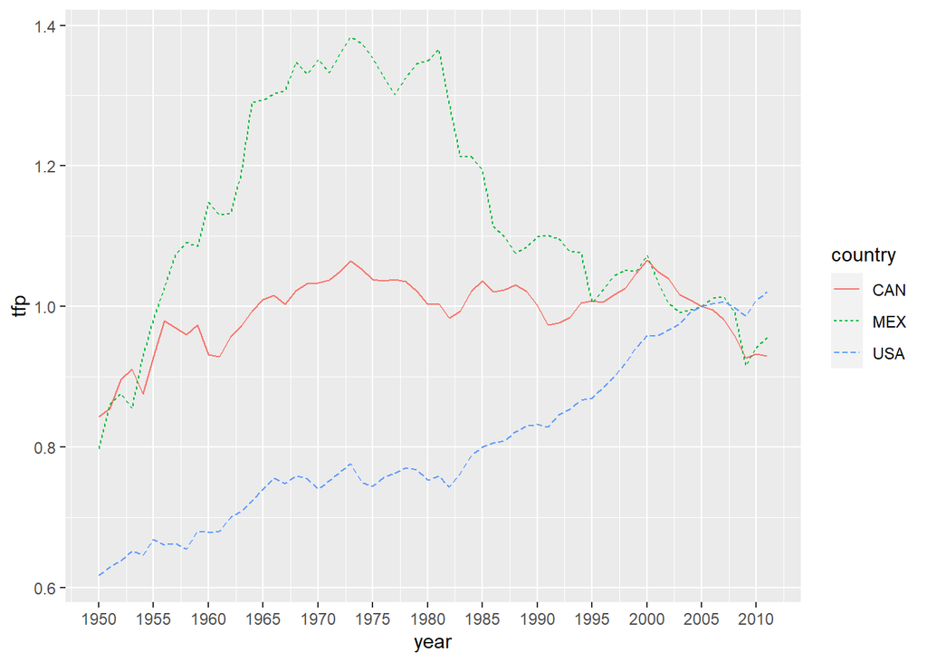

```r
# graph TFP by country
ggplot(data=tfp,aes(x=year,y=tfp,group=country))+ geom_line(aes(linetype=country,color=country))+ scale_x_continuous(breaks = seq(1950, 2011, by = 5))
```

Even though the evolution of TFP is quite different across the countries, the pattern for each series seems reasonable. Hence, apparently there is no misreports or outliers in the data. We also compute the first moments and the distribution of TFP for each country. In order to make things easier first we organize the data in a more convenient way

```r
# reshape
tfp2<-tfp%>%
  reshape(timevar = "country",idvar="year",direction="wide")
tfp2<-tfp2%>%
  dplyr::rename(USA="tfp.USA",
                MEX="tfp.MEX",
                CAN="tfp.CAN")
```

```r
# calculate mean and standard deviation for each country
tfp %>%
dplyr::group_by(country)%>%
summarise(mean=mean(tfp),sd=sd(tfp))
```

```
## # A tibble: 3 x 3
##   country  mean     sd
##   <chr>   <dbl>  <dbl>
## 1 CAN     0.993 0.0501
## 2 MEX     1.13  0.158
## 3 USA     0.804 0.116
```

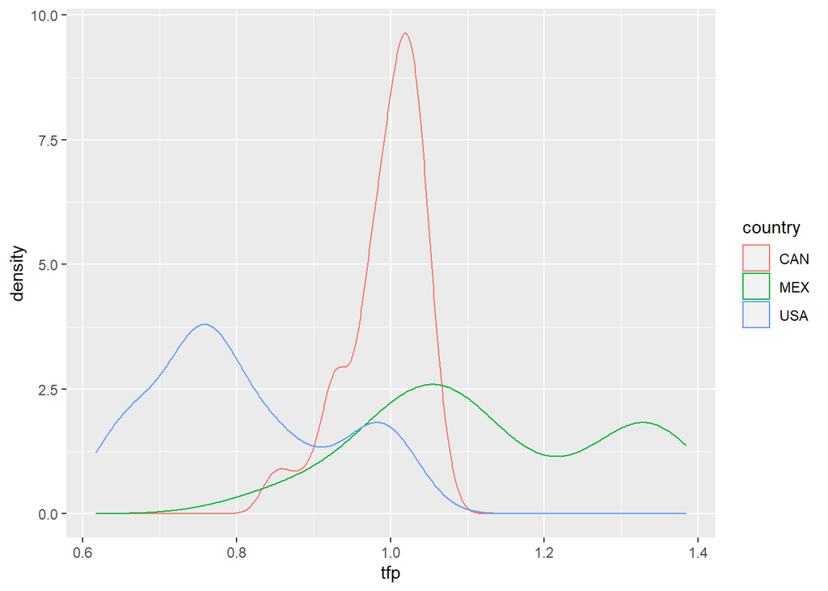

```r
# distribution
ggplot(data=tfp, aes(x=tfp, colour=country)) + geom_density()
```

Finally, we compute the correlation between the countries.

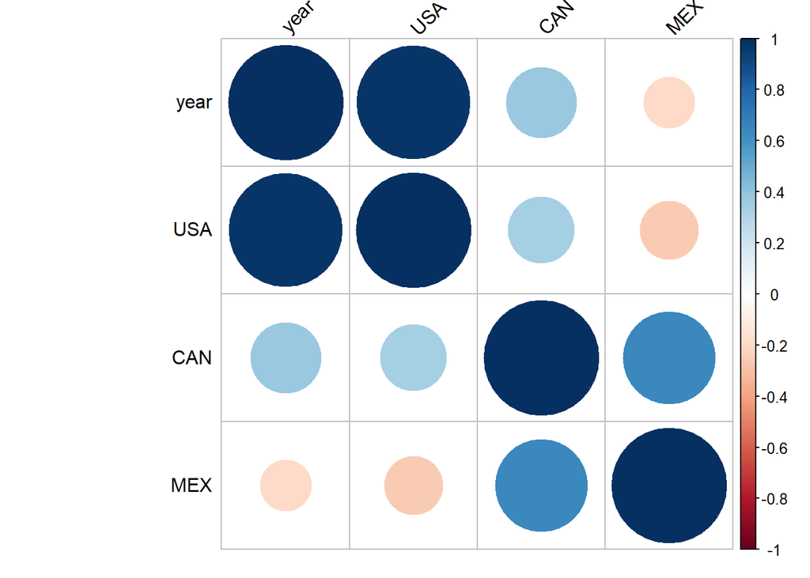

```r
cor<-cor(tfp2)
corrplot(cor, type = "full", order = "hclust",
         tl.col = "black", tl.srt = 45)
```

### 1.2 Forecast

In order to forecast the TFP series, we first define the data as time series.

```r
# define time series
time<-ts(tfp2)

# checking data
head(time)
```

```
## Time Series:
## Start = 1
## End = 6
## Frequency = 1
##   year       USA       CAN       MEX
## 1 1950 0.6171479 0.8433348 0.7981593
## 2 1951 0.6295884 0.8551230 0.8609314
## 3 1952 0.6384513 0.8964893 0.8769677
## 4 1953 0.6518582 0.9106582 0.8552045
## 5 1954 0.6461794 0.8751778 0.9291679
## 6 1955 0.6687729 0.9276822 0.9818486
```

We begin with the simplest forecast function:

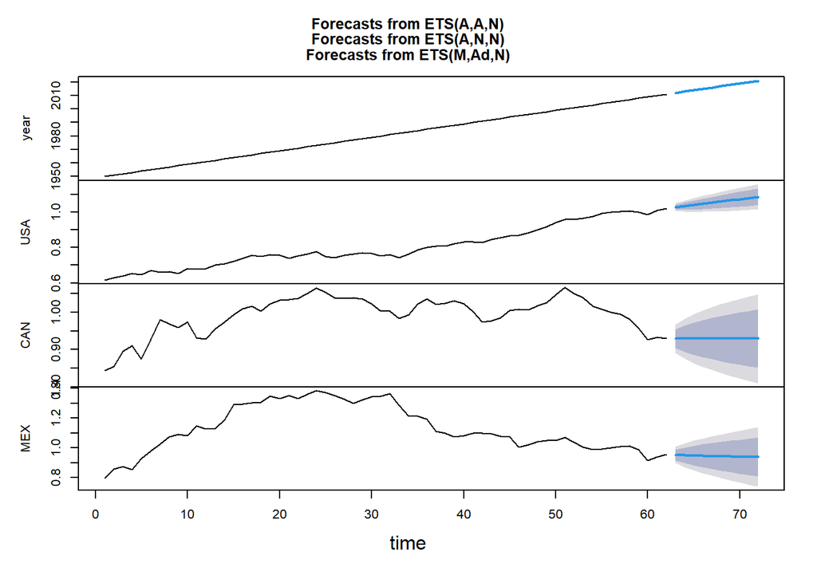

```r
# 10 periods forecast
forecast<-forecast(time,h=10)

# plot forecast
plot(forecast)
```

Now we an alternative approach by using Holter’s exponential smoother

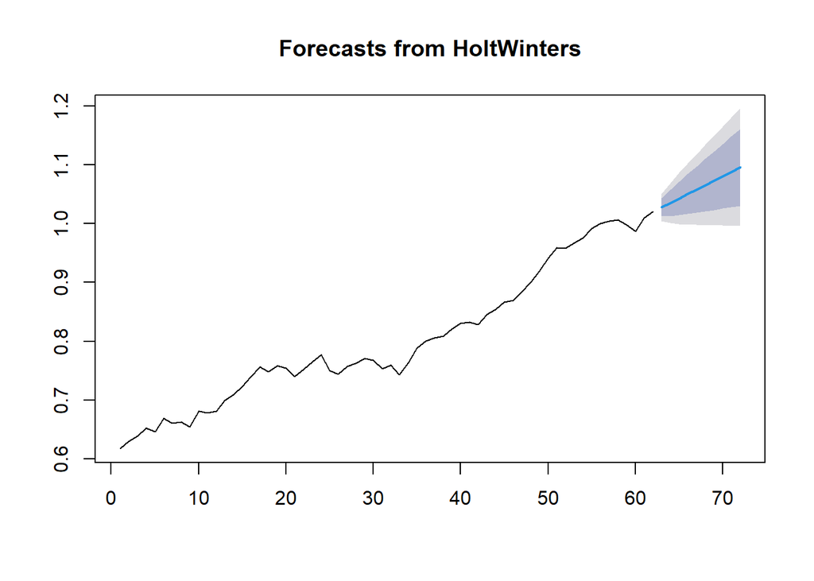

```r
# USA
usa<-tfp2%>%
dplyr::select(USA)
usa<-ts(usa)
usa<-HoltWinters(usa,gamma=FALSE)
usa<-forecast:::forecast.HoltWinters(usa,h=10)
plot(usa)
```

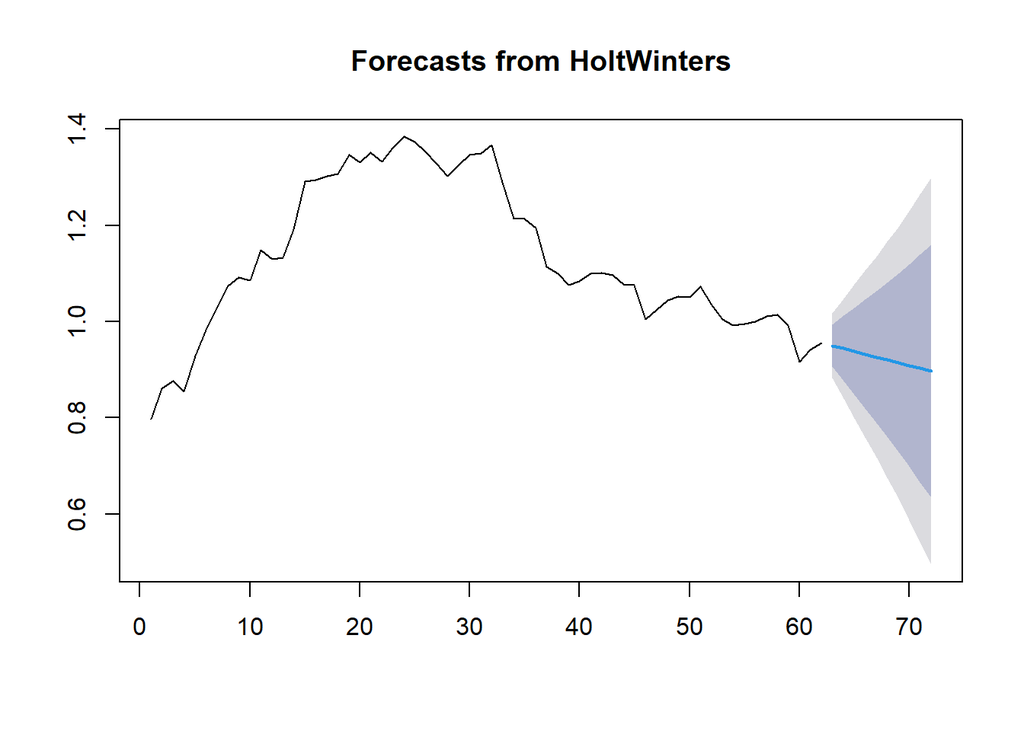

```r
# MEX
mex<-tfp2%>%
dplyr::select(MEX)
mex<-ts(mex)
mex<-HoltWinters(mex,gamma=FALSE)
mex<-forecast:::forecast.HoltWinters(mex,h=10)
plot(mex)
```

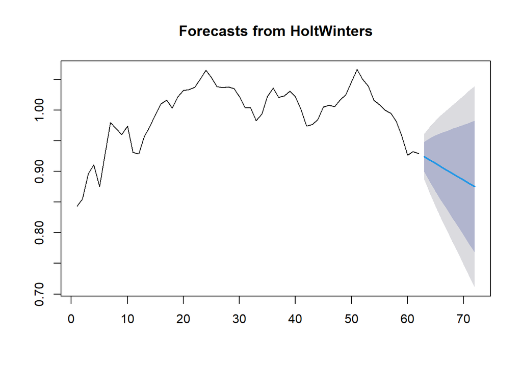

```r
# CAN
can<-tfp2%>%
dplyr::select(CAN)
can<-ts(can)
can<-HoltWinters(can,gamma=FALSE)
can<-forecast:::forecast.HoltWinters(can,h=10)
plot(can)
```

And then, we analyze the residuals from these forecasts

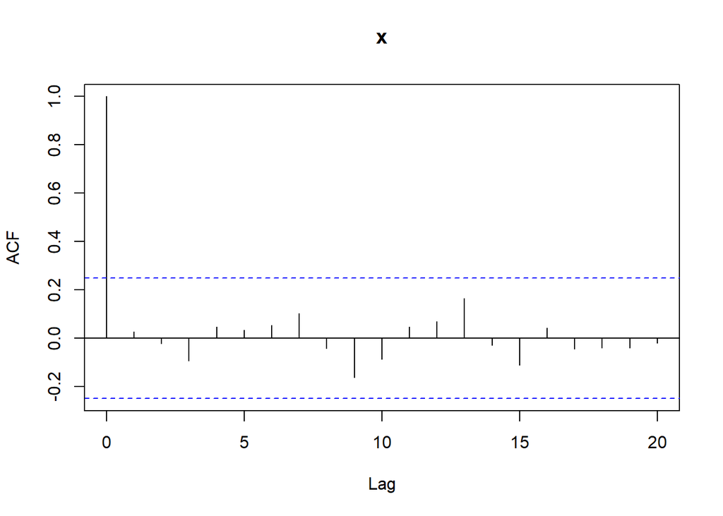

```r
# USA
acf(usa$residuals, lag.max=20,na.action = na.pass)
```

```r
Box.test(usa$residuals, lag=20, type="Ljung-Box")
```

```
##
##  Box-Ljung test
##
## data:  usa$residuals
## X-squared = 8.7956, df = 20, p-value = 0.9852
```

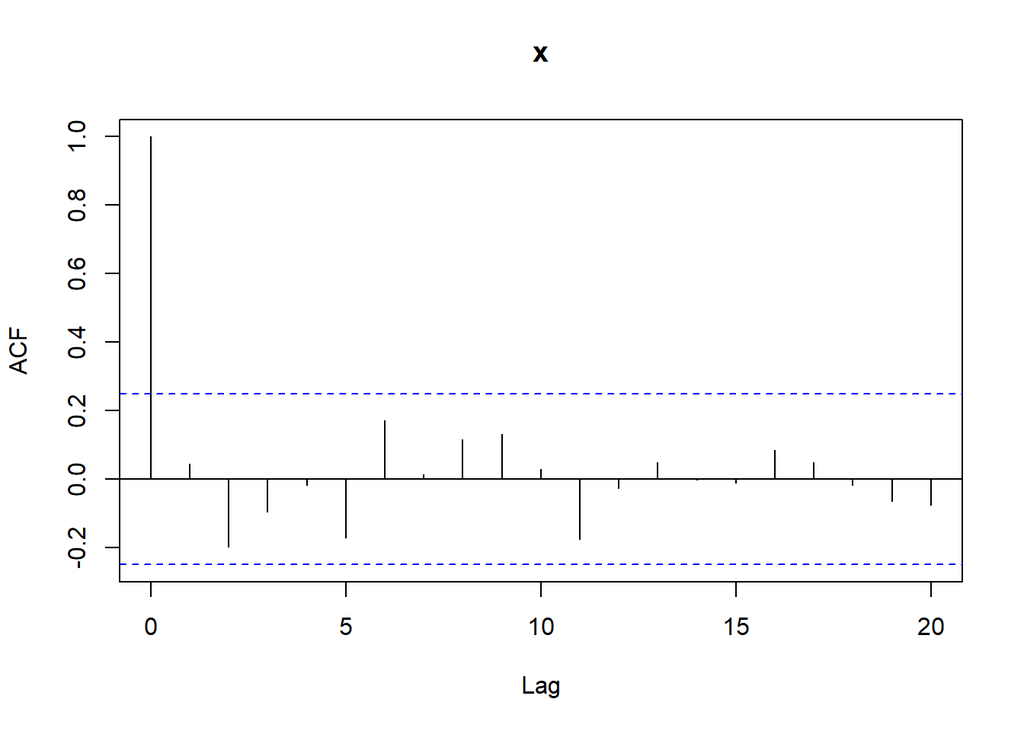

```r
# MEX
acf(mex$residuals, lag.max=20,na.action = na.pass)
```

```r
Box.test(mex$residuals, lag=20, type="Ljung-Box")
```

```
##
##  Box-Ljung test
##
## data:  mex$residuals
## X-squared = 13.828, df = 20, p-value = 0.8391
```

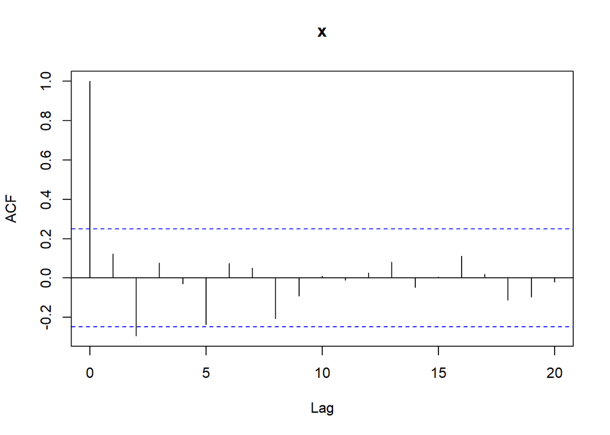

```r
# CAN
acf(can$residuals, lag.max=20,na.action = na.pass)
```

```r
Box.test(can$residuals, lag=20, type="Ljung-Box")
```

```
##
##  Box-Ljung test
##
## data:  can$residuals
## X-squared = 18.812, df = 20, p-value = 0.5341
```

### 1.3 Other variables

There are several features that can help to predict TFP. Since TFP is a measure of productivity, among the variables available at Penn World Table human capital is clearly an important one to explain TFP series since higher levels of education are on average associated with higher levels of productivity.

## 2. Case 2

Now we are provided data on the series of imports and exports in Brazil for a large set of products. We are asked to explore this data and then to do forecasts on the commercial relationship in the next 11 years. Again we begin by importing the data.

```r
# load additional libraries
library(lubridate) # date
library(vars)      # forecast
# import data base
trade <- read.csv("data_comexstat.csv")
```

### 2.1 Soybean exports

First we are asked to show the evolution of total monthly and total annual exports of soybeans, soybean oil and soybean meal. We begin by checking the variables in the dataset and then the categories related to products exported/imported.

```r
ls(trade)
```

```
## [1] "country" "date"    "product" "route"   "state"   "tons"    "type"
## [8] "usd"
```

```r
unique(trade$product)
```

```
## [1] "corn"         "soybean_meal" "soybean_oil"  "soybeans"     "sugar"
## [6] "wheat"
```

Now we estimate the total monthly exports of these products. In order to do this first we keep only observations on exports and on these products. Then, we aggregate, i.e., we sum the tons of export for them.

```r
# keep only exports and selected products
ex1<-trade%>%
dplyr::filter(type=="Export")%>%
dplyr::filter(product=="soybeans"|product=="soybean_oil"|product=="soybean_meal")

# collapse data by product and date
ex1<-ex1%>%
dplyr::group_by(product,year=year(date),month=month(date))%>%
dplyr::summarize(tons=sum(tons),usd=sum(usd))
ex1<-ex1%>%
dplyr::mutate(date=paste(year,month))

# also compute the total exports of all products together
total<-ex1%>%
dplyr::group_by(year,month,date)%>%
dplyr::summarize(tons=sum(tons),usd=sum(usd))%>%
dplyr::mutate(product="total")
```

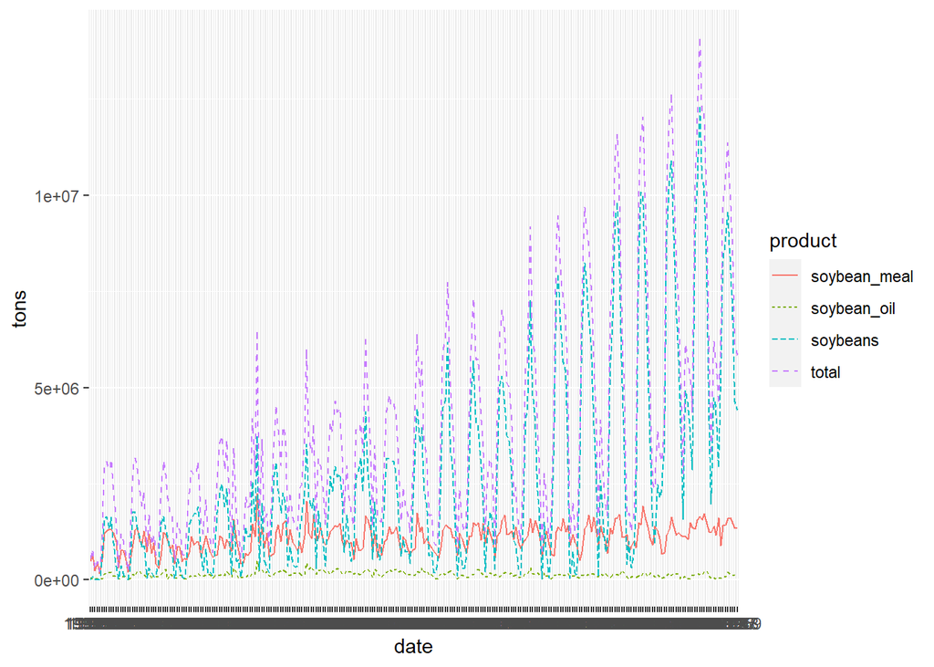

```r
ex1<-rbind(ex1,total) # merge total with individual products

# plot tons
ggplot(data=ex1,aes(x=date,y=tons,group=product))+ geom_line(aes(linetype=product,color=product))
```

In USD the evolution of these exports were given by:

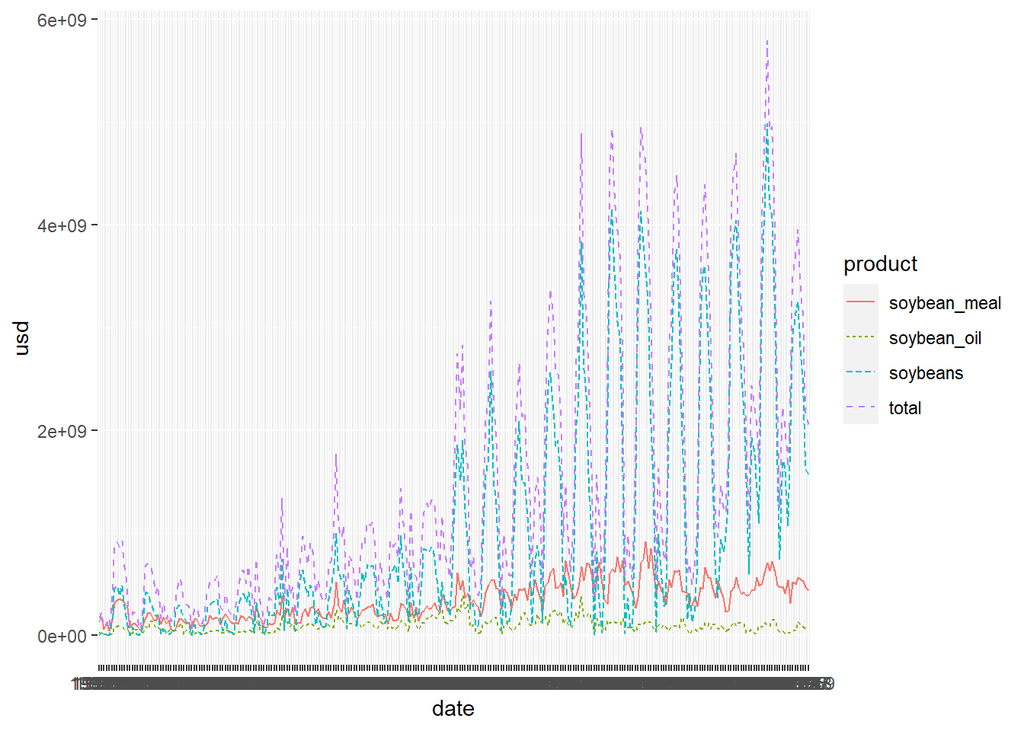

```r
# plot usd
ggplot(data=ex1,aes(x=date,y=usd,group=product))+ geom_line(aes(linetype=product,color=product))
```

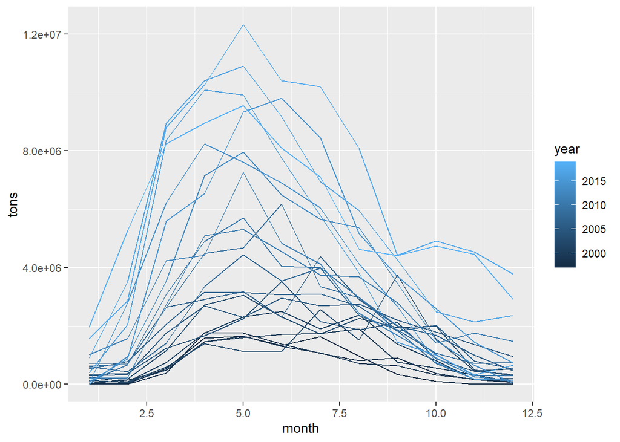

```r
# soybeans
ex1%>%
dplyr::filter(product=="soybeans")%>%
ggplot(aes(x=month,y=tons,group=year))+ geom_line(aes(color=year))
```

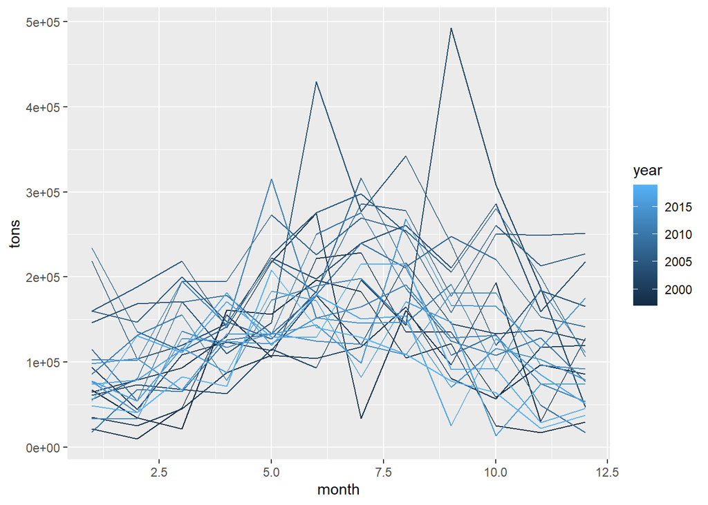

```r
# soybean_oil
ex1%>%
dplyr::filter(product=="soybean_oil")%>%
ggplot(aes(x=month,y=tons,group=year))+ geom_line(aes(color=year))
```

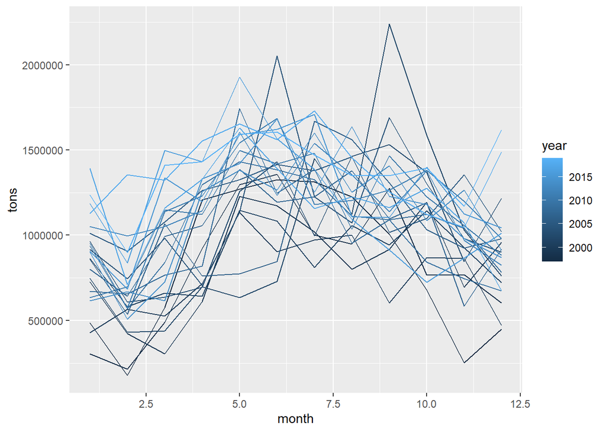

```r
# soybean_meal
ex1%>%
dplyr::filter(product=="soybean_meal")%>%
ggplot(aes(x=month,y=tons,group=year))+ geom_line(aes(color=year))
```

Now we further aggregate exports in terms of years.

```r
# collapse again but now in terms of year and not month
ex1<-ex1%>%
dplyr::group_by(product,year)%>%
dplyr::summarize(tons=sum(tons),usd=sum(usd))
# compute the overall total (for all products together)
total<-ex1%>%
dplyr::group_by(year)%>%
dplyr::summarize(tons=sum(tons),usd=sum(usd))%>%
dplyr::mutate(product="total")
```

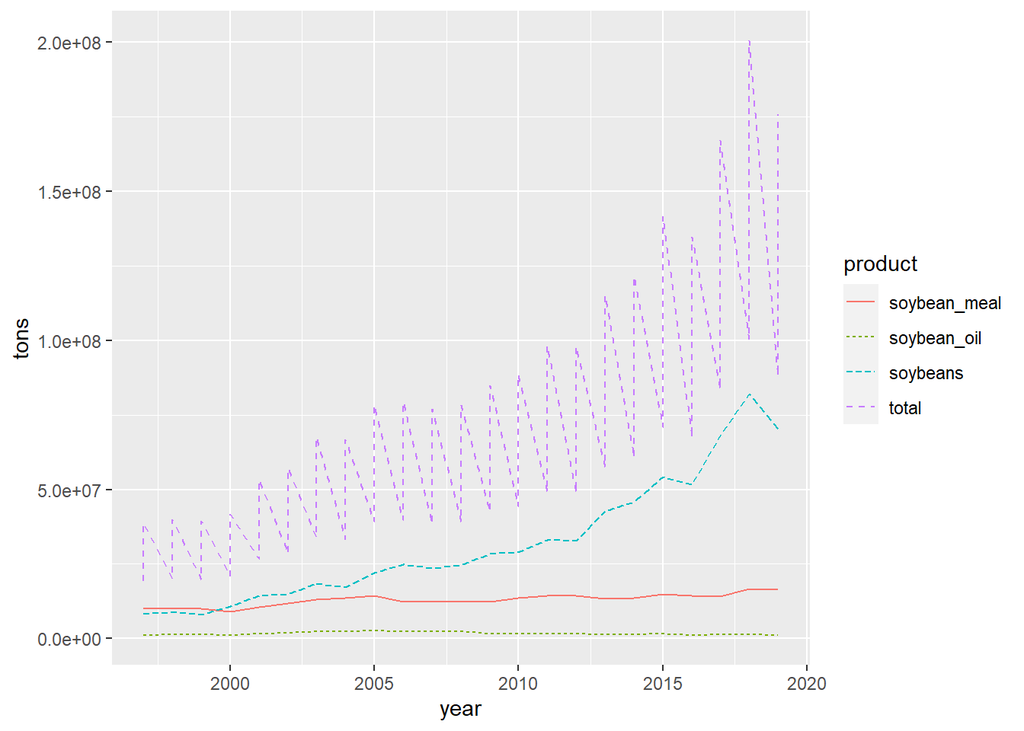

```r
ex1<-rbind(ex1,total) # merge total with individual data

# plot tons
ggplot(data=ex1,aes(x=year,y=tons,group=product))+ geom_line(aes(linetype=product,color=product))
```

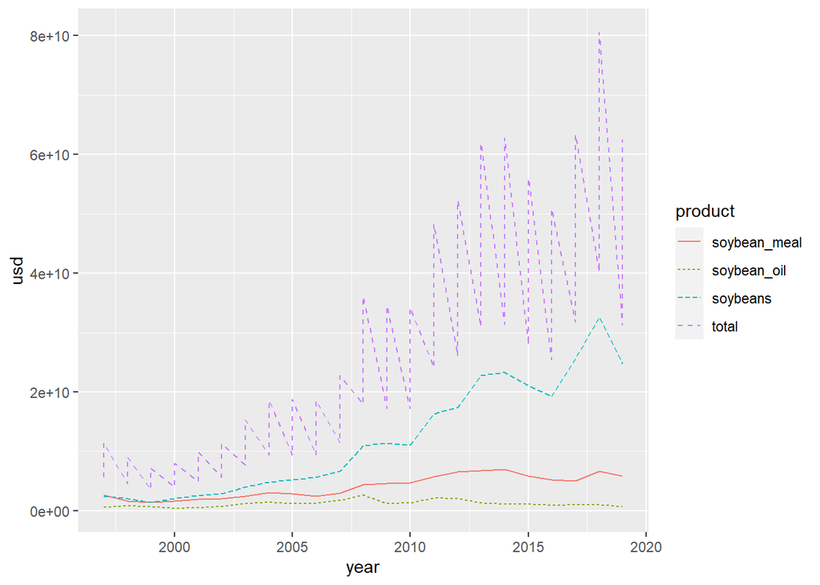

```r
# plot usd
ggplot(data=ex1,aes(x=year,y=usd,group=product))+ geom_line(aes(linetype=product,color=product))
```

### 2.2 Most important exports in last 5 year

Next we are asked about the 3 most important products exported by Brazil in the last 5 years. Again we start by keeping only observations that satisfy this requirement. In particular we drop all observations prior to 5 years from the last observation and observations on imports.

```r
# keep selected years
last(year(trade$date))-5 # first year to be considered
```

```
## [1] 2014
```

```r
ex2<-trade%>%
dplyr::filter(year(date)>last(year(trade$date))-5)%>%
dplyr::filter(type=="Export")

# collapse USD exports by product
ex2<-ex2%>%
dplyr::group_by(product)%>%
dplyr::summarize(usd=sum(usd))
# sort products by their importance (in terms of USD exports)
ex2<-ex2%>%
dplyr::arrange(desc(usd))

head(ex2,3)
```

```
## # A tibble: 3 x 2
##   product               usd
##   <chr>               <dbl>
## 1 soybeans     123325529857
## 2 sugar         40938486021
## 3 soybean_meal  28407723437
```

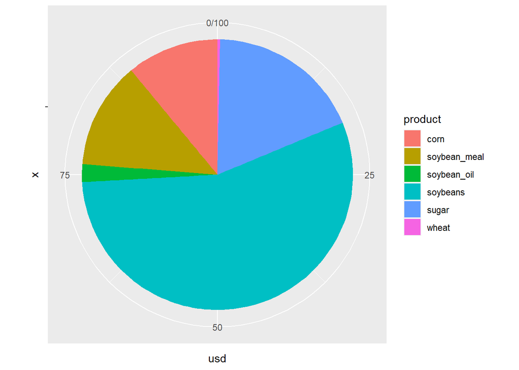

```r
# calculate shares to build pie chart
total<-ex2%>%
dplyr::summarize(total=sum(usd))# total of all products
ex2<-cbind(ex2,total) # merge total with individual data
ex2<-ex2%>%
dplyr::mutate(usd=round(100*usd/total,2))%>%
dplyr::select(-c(total))

# plot pie chart
ggplot(data=ex2,aes(x="",y=usd,fill=product))+
geom_bar(width = 1, stat = "identity")+
  coord_polar("y", start=0)
```

As can be seen soybeans is the main product exported by Brazil in the last five years, representing 55,39 percent of Brazilian exports.

Now we evaluate the main routes through which Brazil have been exporting corn in the last few years. Here we thing in the last few years in terms of the last 3 years of data.

```r
# filter
last(year(trade$date))-3 # first year to be considered
```

```
## [1] 2016
```

```r
ex3<-trade%>%
dplyr::filter(year(date)>last(year(trade$date))-3)%>%
dplyr::filter(type=="Export")

# checking data
unique(ex3$type)
```

```
## [1] "Export"
```

```r
unique(ex3$product)
```

```
## [1] "corn"         "soybean_meal" "soybean_oil"  "soybeans"     "sugar"
## [6] "wheat"
```

```r
# aggregate data for each product and route
ex3<-ex3%>%
dplyr::group_by(product,route)%>%
dplyr::summarize(tons=sum(tons))
# sort data
ex3<-ex3%>%
dplyr::arrange(product,desc(tons))

# main route for corn export
ex3%>%
dplyr::filter(product=="corn")
```

```
## # A tibble: 5 x 3
## # Groups:   product [1]
##   product route       tons
##   <chr>   <chr>      <dbl>
## 1 corn    Sea    90023406.
## 2 corn    River   3500016.
## 3 corn    Other    262436.
## 4 corn    Ground    48246.
## 5 corn    Air         416.
```

Hence, the main route through which corn is exported is sea, followed by river. Now we analyze whether there are differences in the relative importance of routes depending on the product.

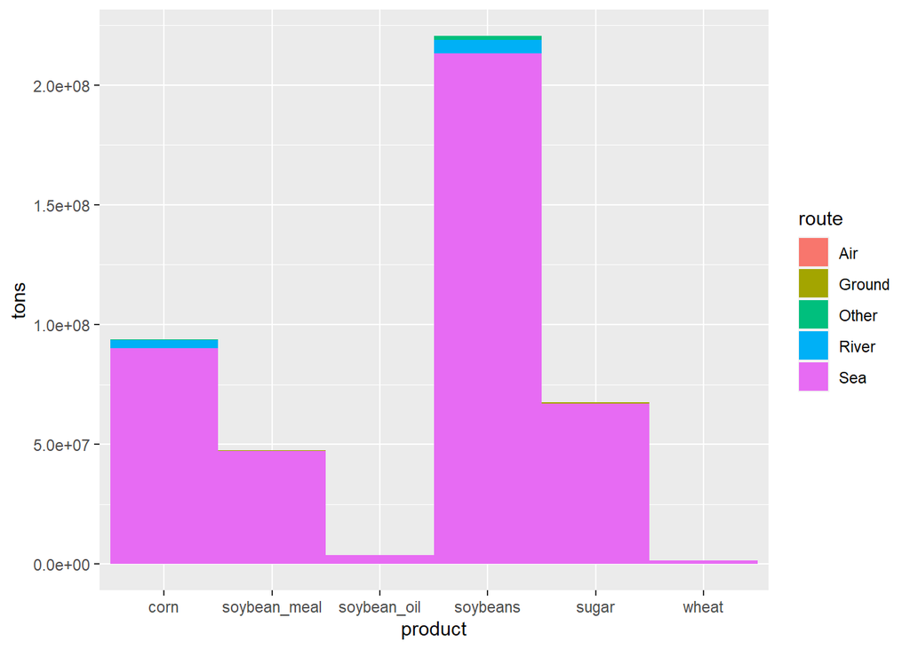

```r
ggplot(data=ex3,aes(x=product,y=tons,fill=route))+
geom_bar(width = 1, stat = "identity")
```

As figure shows, for the other products sea is the main export route.

### 2.4 Most important corn and sugar trade partners in last 3 years

Now we evaluate the main trade partners for corn and sugar over the last 3 years.

```r
# filters
last(year(trade$date))-3
```

```
## [1] 2016
```

```r
ex4<-trade%>%
dplyr::filter(year(date)>last(year(trade$date))-3)%>% # last 3 years
dplyr::filter(product=="corn"|product=="sugar")       # imports/exports of corn and sugar

# aggregate corn and sugar trade by country
ex4<-ex4%>%
dplyr::group_by(country)%>%
dplyr::summarize(usd=sum(usd))
# sort trade in terms of USD
ex4<-ex4%>%
dplyr::arrange(desc(usd))

head(ex4)
```

```
## # A tibble: 6 x 2
##   country           usd
##   <chr>           <dbl>
## 1 Iran       3302427878
## 2 Bangladesh 2591053578
## 3 Algeria    2441462244
## 4 Egypt      2385649201
## 5 Malaysia   1735364581
## 6 India      1704340332
```

The main trade partners of corn and sugar with Brazil are Iran, Bangladesh and Algeria.

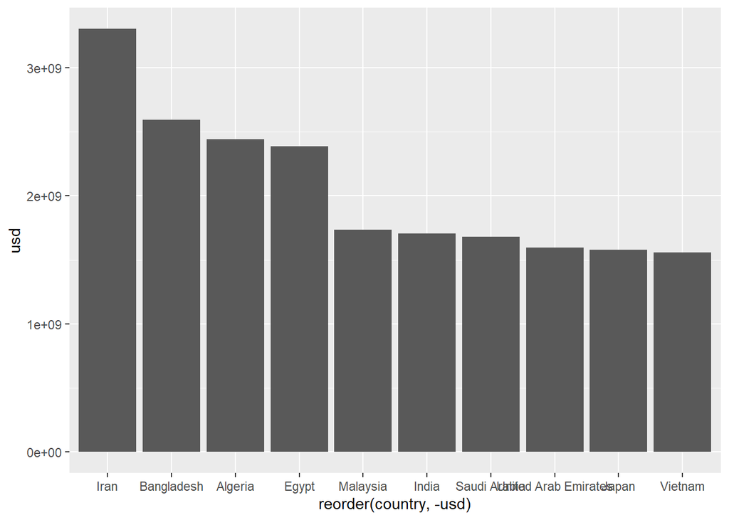

```r
# keep only top 10 partners
ex4<-ex4%>%
dplyr::arrange(desc(usd))%>%
dplyr::mutate(rank=row_number())%>%
dplyr::filter(rank<=10)

# plot
ggplot(data=ex4,aes(x=reorder(country, -usd),y=usd))+ geom_bar(stat="identity")
```

### 2.5 Most important states in terms of exports for each product

Now we evaluate the five most important states in terms of exports for each product

```r
# filter
last(year(trade$date))-3
```

```
## [1] 2016
```

```r
ex5<-trade%>%
dplyr::filter(year(date)>last(year(trade$date))-3)%>%
dplyr::filter(type=="Export")

# aggregate exports by product and state
ex5<-ex5%>%
dplyr::group_by(product,state)%>%
dplyr::summarize(usd=sum(usd))
# sort
ex5<-ex5%>%
dplyr::group_by(product)%>%
dplyr::mutate(rank = row_number(desc(usd)))%>%
dplyr::filter(rank <= 5) %>%
dplyr::arrange(product,desc(rank))

ex5
```

```
## # A tibble: 30 x 4
## # Groups:   product [6]
##    product      state         usd  rank
##    <chr>        <chr>       <dbl> <int>
##  1 corn         SP      429869136     5
##  2 corn         MS      886357880     4
##  3 corn         PR     1511169840     3
##  4 corn         GO     1699670461     2
##  5 corn         MT    10036492224     1
##  6 soybean_meal BA     1048984769     5
##  7 soybean_meal GO     2350365249     4
##  8 soybean_meal RS     2390082997     3
##  9 soybean_meal PR     3560013088     2
## 10 soybean_meal MT     6205779717     1
## # ... with 20 more rows
```

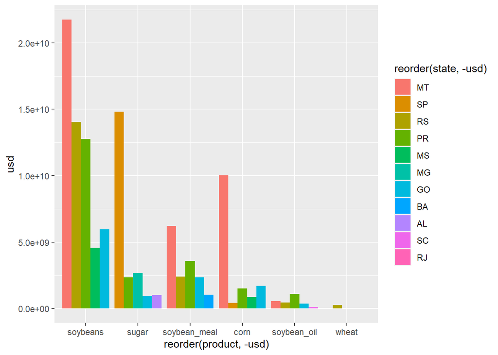

```r
# plot
ggplot(data=ex5,aes(x=reorder(product,-usd),y=usd,fill=reorder(state,-usd)))+ geom_bar(stat="identity", position=position_dodge())
```

### 2.6 Forecast export soybeans, soybean_meal, and corn for the next 11 years (2020-2030)

Finally, we provide annual forecast for soybeans, soybean_meal, and corn over the next 11 years.

```r
# filter
ex6<-trade%>%
dplyr::filter(product=="soybeans"|product=="soybean_meal"|product=="corn")
ex6<-ex6%>%
dplyr::filter(type=="Export")

# keep only variables of interest
ex6<-ex6%>%
dplyr::select(-c(state,country,type,route,usd))

# collapse monthly
ex6<-ex6%>%
dplyr::group_by(product,year=year(date))%>%
dplyr::summarize(tons=sum(tons))
# reshape
ex6<-ex6%>%
spread(product,tons)
ex6<-ex6%>%dplyr::select(-c(year))

# time series
ex6<-ts(ex6)

# lag selection for VAR
lagselect <- VARselect(ex6, lag.max = 15, type = "const")
lagselect$selection
```

```
## AIC(n)  HQ(n)  SC(n) FPE(n)
##      3      3      3      3
```

```r
# var estimation
est <- VAR(ex6, p = 3, type = "trend", season = NULL, exog = NULL)
summary(est)
```

```
##
## VAR Estimation Results:
## =========================
## Endogenous variables: corn, soybean_meal, soybeans
## Deterministic variables: trend
## Sample size: 20
## Log Likelihood: -957.066
## Roots of the characteristic polynomial:
## 1.083 1.002 1.002  0.95 0.8615 0.7361 0.7361 0.526 0.526
## Call:
## VAR(y = ex6, p = 3, type = "trend", exogen = NULL)
##
##
## Estimation results for equation corn:
## =====================================
## corn = corn.l1 + soybean_meal.l1 + soybeans.l1 + corn.l2 + soybean_meal.l2 + soybeans.l2 + corn.l3 + soybean_meal.l3 + soybeans.l3 + trend
##
##                   Estimate Std. Error t value Pr(>|t|)
## corn.l1          1.194e-01  2.895e-01   0.413   0.6886
## soybean_meal.l1 -1.713e+00  1.094e+00  -1.566   0.1485
## soybeans.l1      3.934e-01  2.882e-01   1.365   0.2022
## corn.l2          9.491e-02  3.120e-01   0.304   0.7672
## soybean_meal.l2  2.447e+00  1.701e+00   1.438   0.1809
## soybeans.l2      6.236e-01  3.894e-01   1.602   0.1403
## corn.l3         -9.428e-02  3.238e-01  -0.291   0.7769
## soybean_meal.l3 -1.541e+00  1.263e+00  -1.220   0.2504
## soybeans.l3     -1.088e+00  4.501e-01  -2.418   0.0362 *
## trend            1.497e+06  8.900e+05   1.682   0.1235
## ---
## Signif. codes:  0 '***' 0.001 '**' 0.01 '*' 0.05 '.' 0.1 ' ' 1
##
##
## Residual standard error: 4333000 on 10 degrees of freedom
## Multiple R-Squared: 0.971,   Adjusted R-squared: 0.942
## F-statistic: 33.51 on 10 and 10 DF,  p-value: 2.335e-06
##
##
## Estimation results for equation soybean_meal:
## =============================================
## soybean_meal = corn.l1 + soybean_meal.l1 + soybeans.l1 + corn.l2 + soybean_meal.l2 + soybeans.l2 + corn.l3 + soybean_meal.l3 + soybeans.l3 + trend
```

[output cut: 40 more lines]

```
## F-statistic: 125.8 on 10 and 10 DF,  p-value: 3.749e-09
##
##
##
## Covariance matrix of residuals:
##                    corn soybean_meal  soybeans
## corn          1.877e+13   -1.453e+12 1.435e+12
## soybean_meal -1.453e+12    1.717e+12 3.114e+12
## soybeans      1.435e+12    3.114e+12 2.612e+13
##
## Correlation matrix of residuals:
##                  corn soybean_meal soybeans
## corn          1.00000       -0.256  0.06479
## soybean_meal -0.25601        1.000  0.46501
## soybeans      0.06479        0.465  1.00000
```

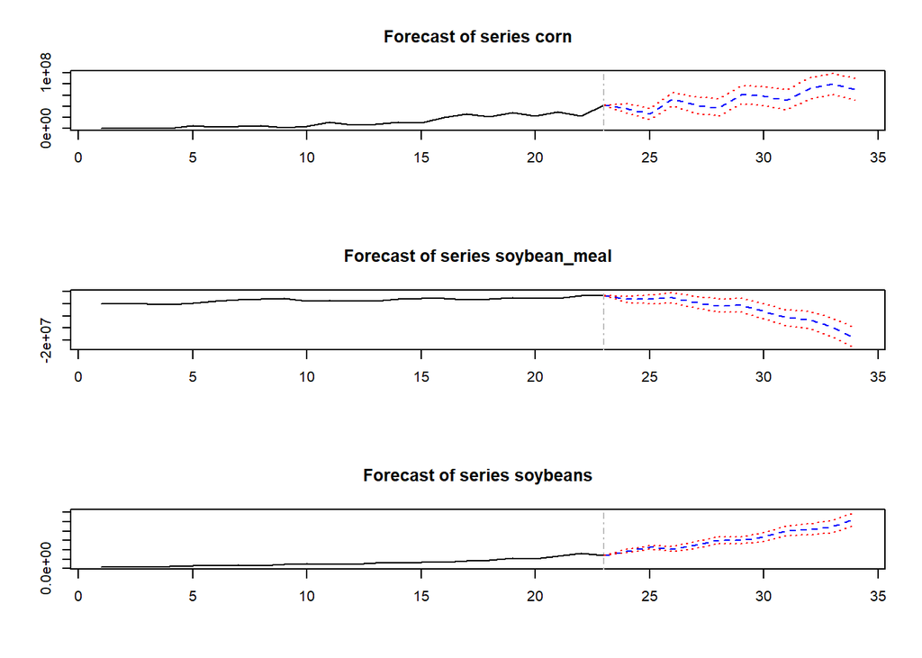

```r
# forecast
ex6 <- predict(est, n.ahead = 11, ci = 0.95)
plot(ex6)
```

```r
forecast
```

```
## year
##    Point Forecast Lo 80 Hi 80 Lo 95 Hi 95
## 63           2012  2012  2012  2012  2012
## 64           2013  2013  2013  2013  2013
## 65           2014  2014  2014  2014  2014
## 66           2015  2015  2015  2015  2015
## 67           2016  2016  2016  2016  2016
## 68           2017  2017  2017  2017  2017
## 69           2018  2018  2018  2018  2018
## 70           2019  2019  2019  2019  2019
## 71           2020  2020  2020  2020  2020
## 72           2021  2021  2021  2021  2021
##
## USA
##    Point Forecast    Lo 80    Hi 80    Lo 95    Hi 95
```

[output cut: 36 more lines]